# Practical machine learning project

### Training set data

The Weight Lifting Exercises dataset was collected by

Ugulino, W.; Cardador, D.; Vega, K.; Velloso, E.; Milidiu, R.; Fuks, H. **Wearable Computing: Accelerometers’ Data Classification of Body Postures and Movements**. Proceedings of 21st Brazilian Symposium on Artificial Intelligence. Advances in Artificial Intelligence - SBIA 2012. In: Lecture Notes in Computer Science. , pp. 52-61. Curitiba, PR: Springer Berlin / Heidelberg, 2012. ISBN 978-3-642-34458-9. DOI: 10.1007/978-3-642-34459-6_6.

We downloaded their dataset of 19622 observations.

```r
library(RCurl)
dat <- read.csv(text=getURL("https://d396qusza40orc.cloudfront.net/predmachlearn/pml-training.csv"), na.strings=c("NA",""), header=TRUE, stringsAsFactors=FALSE)
```

We divided these 80:20 into training and test sets. The goal was to create a prediction algorithm for the ‘classe’ factor variable, which represents the manner in which subjects performed the given exercise.

```r
library(caret)
set.seed(1)
testIndex = createDataPartition(dat$classe, p=0.8, list=FALSE)
training = dat[testIndex, ]
testing = dat[-testIndex, ]
```

### Selecting covariates

We wanted to eliminate irrelevant covariates from our predictors. The first 7 columns contained subject and time labels, so we removed these.

```r
head(training[, 1:7], 3)
```

```
##   X user_name raw_timestamp_part_1 raw_timestamp_part_2   cvtd_timestamp
## 2 2  carlitos           1323084231               808298 05/12/2011 11:23
## 3 3  carlitos           1323084231               820366 05/12/2011 11:23
## 4 4  carlitos           1323084232               120339 05/12/2011 11:23
##   new_window num_window
## 2         no         11
## 3         no         11
## 4         no         12
```

```r
training <- training[, 8:160]
testing <- testing[, 8:160]
```

The data had been imported variously by read.csv() as integers, numerics or characters. With the exception of the last column containing the ‘classe’ variable, we converted each column to numeric. The ‘classe’ variable was converted to a factor.

```r
training[, 1:152] <- sapply(training[, 1:152], as.numeric)
testing[, 1:152] <- sapply(testing[, 1:152], as.numeric)
training$classe <- as.factor(training$classe)
testing$classe <- as.factor(testing$classe)
```

#### NA values

Many of the covariates contained a large number of NA values. In fact, covariates either contained zero NAs or close to 100%.

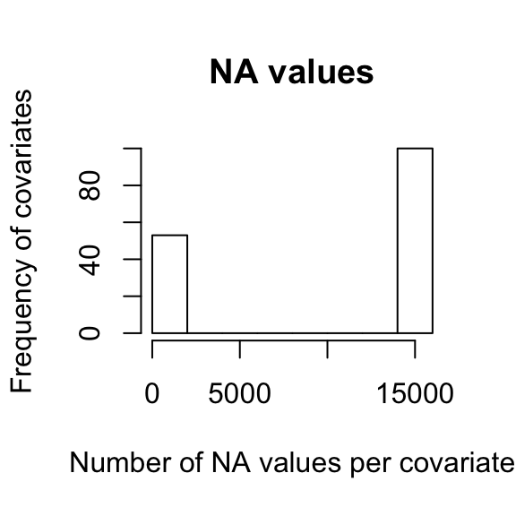

We kept only covariates that did not contain NA values.

```r
columns_to_keep <- colSums(is.na(training)) == 0
training <- training[, columns_to_keep]
testing <- testing[, columns_to_keep]
```

#### Near-zero-variance covariates

We wanted to eliminate any covariates that had near-zero variance. However, after removing covariates with NA values, there were no longer any covariates left with near-zero variance.

```r
nzv <- nearZeroVar(training, saveMetric=TRUE)
sum(nzv$nzv==TRUE)
```

```
## [1] 0
```

### Random forest model

We trained a random forest model

```r
modFit <- train(classe ~ ., data=training, method='rf', prox=TRUE)
```

#### Out-of-sample error

This model gave 100% accuracy on the training set, which might indicate overfitting and potentially high variance.

```r
sum(predict(modFit, training) == training$classe)/nrow(training) * 100
```

```
## [1] 100
```

However, cross-validation with our test set containing 3923 observations also gave close to perfect accuracy and almost no out-of-sample error. We were therefore confident in our classification model.

```r
sum(predict(modFit, testing) == testing$classe)/nrow(testing) * 100
```

```
## [1] 99.4392
```

### Test cases

We applied our model to the 20 test cases supplied.

```r
testCases <- read.csv(text=getURL("https://d396qusza40orc.cloudfront.net/predmachlearn/pml-testing.csv"))
answers <- predict(modFit, testCases)
answers
```

```
##  [1] B A B A A E D B A A B C B A E E A B B B
## Levels: A B C D E
```

```r
pml_write_files = function(x){
  n = length(x)
  for(i in 1:n){
    filename = paste0("problem_id_",i,".txt")
    write.table(x[i],file=filename,quote=FALSE,row.names=FALSE,col.names=FALSE)
  }
}
pml_write_files(answers)
```